# alen-analysis

```python
import pandas as pd
from helpers import bar_chart, create_freq_table

df = pd.read_csv("../data/clean-survey.csv")
```

### Analysis

We begin by setting up our required imports and loading our dataset in for analysis.

> A word of note

> The helpers package is an internal package containing helper modules with functions and constants. Hence, it is custom and may contain logical errors and bugs. Care must be taken when calling these functions

Below we begin analysis of the demographic data. It showcases the distribution and frequencies of the following:

1. Genders
2. Occupation
3. Age-Group
4. Usage-Duration

Remark: It is possible to rewrite the following code blocks concisely in one for loop. However, this will not be done as it will only render the last renderable code block

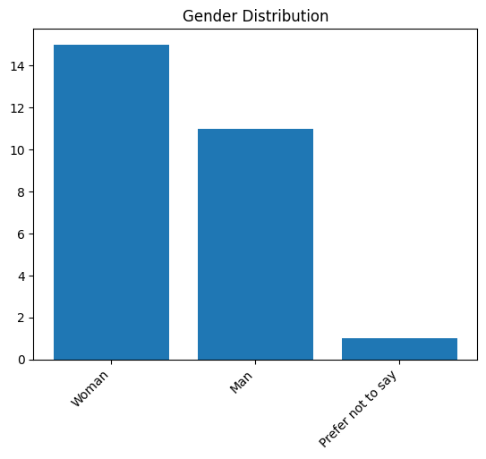

Gender Frequency Table

| gender | Frequency (n) | Distribution (%) |
| --- | --- | --- |
| Woman | 15 | 55.6% |
| Man | 11 | 40.7% |
| Prefer not to say | 1 | 3.7% |

```python
# Gender Distribution & Frequency
gender_counts = df["gender"].value_counts()
gender_proportion = df["gender"].value_counts(normalize=True) * 100

# Distribution
bar_chart(
    categories=gender_counts.index,
    category_freq= list(gender_counts.values),
    title="Gender Distribution"
)

# Summary/Frequency
create_freq_table("Gender Frequency Table", gender_counts, gender_proportion)
```

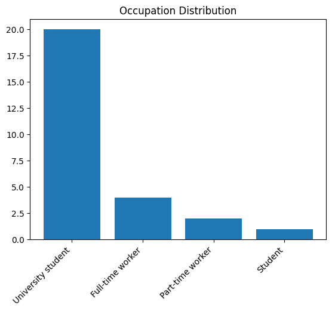

Occupation Frequency Table

| occupation | Frequency (n) | Distribution (%) |
| --- | --- | --- |
| University student | 20 | 74.1% |
| Full-time worker | 4 | 14.8% |
| Part-time worker | 2 | 7.4% |
| Student | 1 | 3.7% |

```python
# Occupation Distribution & Frequency
occupation_count = df["occupation"].value_counts()
occupation_prop = df["occupation"].value_counts(normalize=True) * 100

# Distribution
bar_chart(
    categories=occupation_count.index,
    category_freq= list(occupation_count.values),
    title="Occupation Distribution"
)

# Summary/Frequency
create_freq_table("Occupation Frequency Table", occupation_count, occupation_prop)
```

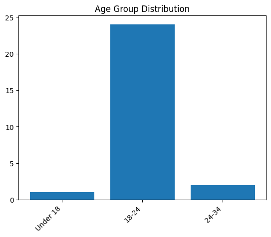

Age Group Frequency Table

| age_group | Frequency (n) | Distribution (%) |
| --- | --- | --- |
| Under 18 | 1 | 3.7% |
| 18-24 | 24 | 88.9% |
| 24-34 | 2 | 7.4% |

```python
# Age-Group Distribution & Frequency
age_group_order = ["Under 18", "18-24", "24-34"]

# Use an explicit re-order as the data is ordinal
age_group_counts = df["age_group"].value_counts().reindex(age_group_order)
age_group_props = (age_group_counts / age_group_counts.sum()) * 100

# Distribution
bar_chart(
    categories=age_group_counts.index,
    category_freq= list(age_group_counts.values),
    title="Age Group Distribution"
)

# Summary/Frequency
create_freq_table("Age Group Frequency Table", age_group_counts, age_group_props)
```

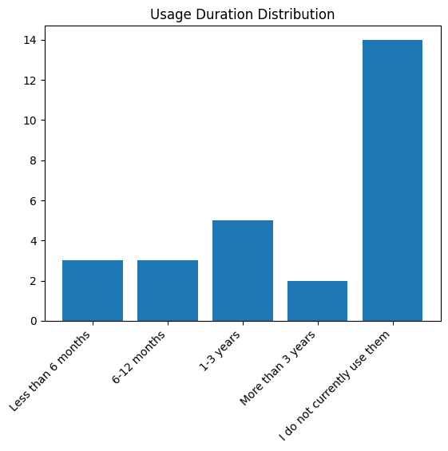

Usage Duration Frequency Table

| usage_duration | Frequency (n) | Distribution (%) |
| --- | --- | --- |
| Less than 6 months | 3 | 11.1% |
| 6-12 months | 3 | 11.1% |
| 1-3 years | 5 | 18.5% |
| More than 3 years | 2 | 7.4% |
| I do not currently use them | 14 | 51.9% |

```python
# Usage-Duration Distribution & Frequency
usage_duration_order = ["Less than 6 months", "6-12 months", "1-3 years", "More than 3 years", "I do not currently use them"]

# We use a custom order again as the data is ordinal
usage_duration_counts = df["usage_duration"].value_counts().reindex(usage_duration_order)
usage_duration_props = (usage_duration_counts / usage_duration_counts.sum()) * 100

# Distribution
bar_chart(
    categories=usage_duration_counts.index,
    category_freq= list(usage_duration_counts.values),
    title="Usage Duration Distribution"
)

# Summary/Frequency
create_freq_table("Usage Duration Frequency Table", usage_duration_counts,usage_duration_props)
```

## Demographic Analysis

From the above we arrive at the following:

1. Surveyees were not primarily from one gender group and was roughly equal
2. A significant amount of surveyees were university students, which was naturally expected as we mainly asked around for surveyees in school
3. Unsurprisingly the largest age-group surveyed coincides with the expected age-group of current university students
4. About half of the surveyed no longer use wearables. However, their willigness to participate in the survey hints to possible unmet needs that caused them to no longer use wearables